# Regresión logística y multinomial

January 2024

## Modelo de regresión logística

**El contexto**

- Deseamos predecir una variable respuesta binaria $Y$ que solo toma los valores 0 y 1.
  - Además, estos valores numéricos solo indicarán la pertenencia o no a un determinado grupo.
- `Ejemplos`:
  - Determinar si un paciente tiene o no una determinada enfermedad en función de diferentes variables (edad, presión arterial, nivel de colesterol, etc.).
    - En este caso el valor 1 suele indicar que sí la tiene y 0 que no.
  - Predecir si un estudiante aprueba o no un examen en función de las horas de estudio.
  - Predecir si un mensaje de correo electrónico es spam o no en función de las palabras clave.
  - Predecir si un cliente comprará o no un determinado producto en función de la edad y el salario.
  - Predecir si un paciente tiene diabetes o no en función de variables como el nivel de glucosa, la presión arterial y el índice de masa corporal (IMC).

**Objetivo**

- `Objetivo`: predecir la variable respuesta $Y$ a partir de $k$ variables numéricas $X_1, \dots, X_k$ utilizando una única función
  $$h_{\boldsymbol \theta}(\mathbf x) = g(\boldsymbol \theta' \mathbf x) = g(\theta_0 + \theta_1 x_1 + \dots + \theta_k x_k) \, ,$$
  donde $\boldsymbol \theta = (\theta_0, \dots, \theta_k)' \in \mathbb R^{k+1}$ contiene los parámetros del modelo y $\mathbf X = (X_0, \dots, X_k)'$ las variables que podemos medir en nuestros individuos para predecir $Y$.
- Para mejorar la notación hemos incluido una variable artificial $X_0$ que siempre vale 1.

**¿Cómo elegir la función $g$?**

- La función $g$ debe transformar esos valores numéricos (lineales) en números entre 0 y 1 que nos indicarán la `probabilidad` de que el individuo pertenezca al grupo ($Y =1$):
  $$g: \mathbb R \rightarrow [0, 1]$$
  y $h_{\boldsymbol \theta}(\mathbf x) \approx Pr(Y = 1 | \mathbf X = \mathbf x)$, donde $\mathbf X = (X_0,\dots,X_k)'$.
- `Regla de decisión`:
  $$\begin{equation*}
  \begin{split}
  & h_{\boldsymbol \theta}(\mathbf x) \geq 0.5 \rightarrow \hat y = 1 \\
  & h_{\boldsymbol \theta}(\mathbf x) < 0.5 \rightarrow \hat y = 0
  \end{split}
  \end{equation*}$$
  donde $\hat y$ representa el valor que predecimos para $Y$ cuando $\mathbf X = \mathbf x$.
- Existen diversas opciones para determinar $g$, la más popular es la `función logística` (o `sigmoide`)
  $$g(z) = \frac{1}{1 + \exp(-z)} =
  \frac{\exp(z)}{1 + \exp(z)} \, .$$

## Función logística

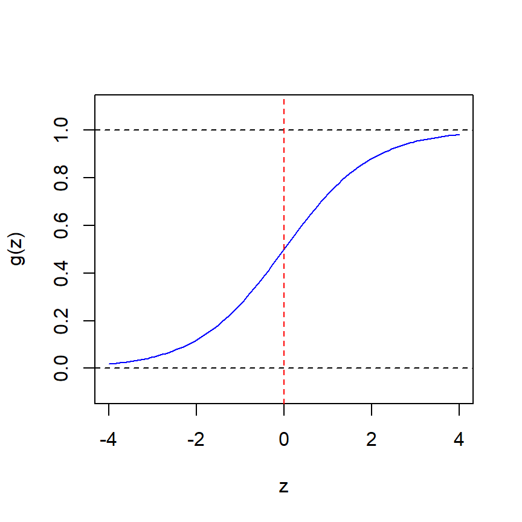

```r
par(mfrow = c(1, 1))
g <- function(x) 1/(1+exp(-x))
x <- seq(-4, 4, length = 100)
y <- g(x)
plot(x, y, xlab = 'z', ylab = 'g(z)', col = 'blue', type = "l",
     ylim = c(-0.1, 1.1), yaxp = c(0, 1, 5))
abline(h = 0, lty = 2)
abline(h = 1, lty = 2)
abline(v = 0, lty = 2, col = "red")
```

**Propiedades**

- Es continua
- Estrictamente creciente
- Recorrido de 0 a 1,
- Transformará el valor $\boldsymbol \theta' \mathbf x \in \mathbb R$ en un valor $h_{\boldsymbol \theta}(\mathbf x) \in [0, 1]$.
- $g(0) = 0.5$
- `Regla de decisión`:
  $$\begin{equation*}
  \begin{split}
  & \boldsymbol \theta ' \mathbf x \geq 0 \, \rightarrow \, \hat y = 1 \\
  & \boldsymbol \theta ' \mathbf x < 0 \, \rightarrow \, \hat y = 0
  \end{split}
  \end{equation*}$$
- La función $I_{\boldsymbol \theta}(\mathbf x) = \boldsymbol \theta ' \mathbf x$ define un `índice de separación` entre las categorías de $Y$.

## ¿Cómo determinar una función costo que penalice las decisiones erróneas?

**Función costo**

- Para $z = h_{\boldsymbol \theta}(\mathbf x)$, definimos la función costo

$$c(z , y ) =
\left \{
\begin{array}{ll}
- \log(z) & \mbox{si } y = 1 \\
- \log(1-z) & \mbox{si } y = 0
\end{array}
\right .$$

- O, equivalentemente,
  $$c(z, y) = - y \log(z) - (1-y) \log(1-z) \, ,$$
  donde $y \in \{0, 1\}$ y los logaritmos son neperianos.

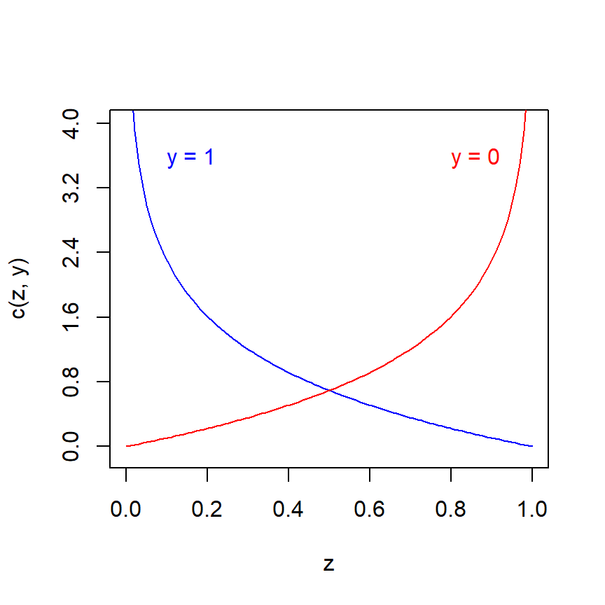

```r
par(mfrow = c(1, 1))
x <- seq(0, 1, length = 100)
plot(x, -log(x), xlab = 'z', ylab = 'c(z, y)', col = 'blue', type = "l",
     ylim = c(-0.1, 4), yaxp = c(0, 4, 5))
text(0.1, 3.5, "y = 1", col = "blue", adj = c(0, 0))
lines(x, -log(1-x), xlab = 'z', ylab = 'c(z, y)', col = 'red', type = "l",
     ylim = c(-0.1, 4), yaxp = c(0, 4, 5))
text(0.8, 3.5, "y = 0", col = "red", adj = c(0, 0))
```

**Criterio**

- Minimizar el valor esperado de la función costo
  $$\min_{\boldsymbol \theta} J(\boldsymbol \theta) = E[c(h_{\boldsymbol \theta}(\mathbf X), Y )]$$
- Para determinar los valores óptimos de los parámetros:
  - Dispondremos de una muestra (`training sample`) de individuos en los que se conozcan tanto los valores de $\mathbf x$ como los valores de $y$ (`aprendizaje supervisado`).
  - Calcularemos los costos en los valores muestrales.
  - Determinaremos los valores de los parámetros $\boldsymbol \theta$ que minimizan estos costos.

**Otra formulación del problema**

- Si $p = Pr(Y = 1)$ este modelo es equivalente a suponer que existe una relación lineal entre las variables $X_1, \dots, X_k$ y la función `log-odd de p`
  $$\log \frac{p}{1 - p}
  = \boldsymbol \theta' \mathbf X .$$
- Puesto que esto es equivalente a suponer que
  $$p = Pr(Y = 1) = \frac{\exp(\boldsymbol \theta' \mathbf X)}{1 + \exp(\boldsymbol \theta ' \mathbf X)}
  = g(\boldsymbol \theta' \mathbf X)$$

## Inferencia y predicción

**Función de costo empírica**

- Datos muestrales: $(\mathbf x^{(1)}, y^{(1)}), \dots, (\mathbf x^{(n)}, y^{(n)}) \, .$
- Función de costo:
  $$J(\boldsymbol \theta) :=
  \frac{1}{n} \sum_{i=1}^n
  c(h_{\boldsymbol \theta}(\mathbf x^{(i)}), y^{(i)}) \,.$$
- Desarrollando la función $c$ obtenemos
  $$\begin{equation*}
  \begin{split}
  J(\boldsymbol \theta) & = - \frac{1}{n} \sum_{i=1}^n
  [
  y^{(i)} \log(h_{\boldsymbol \theta}(\mathbf x^{(i)})) + (1 - y^{(i)}) \log(1 - h_{\boldsymbol \theta}(\mathbf x^{(i)}))
  ]
  \\
  & = -
  \frac{1}{n} \sum_{i=1}^n
  [
  y^{(i)} \log(g(\boldsymbol \theta ' \mathbf x^{(i)})) + (1 - y^{(i)}) \log(1 - g(\boldsymbol \theta ' \mathbf x^{(i)}))
  ]
  \end{split}
  \end{equation*}$$

**Función de costo empírica en forma matricial**

- Denotando
  - $M = (x_j^{(i)})$ a la matriz de datos,
  - $\mathbf y = (y^{(i)})$ al vector columna con los valores de $Y$ y
  - $h := g(M \boldsymbol \theta)$ al vector columna con los ajustes en cada individuo, entonces
    $$J(\boldsymbol \theta) := - \frac{1}{n} [\mathbf y' \log(h) + (\mathbf 1_n - \mathbf y)' \log(\mathbf 1_n - h) ]$$
    donde $\mathbf 1_n$ representa un vector columna de dimensión $n$.

**Objetivo**

- Ajustar el parámetro $\boldsymbol \theta$ para que $J$ tome el menor valor posible.
  - `Solución` $\rightarrow$ Algoritmos iterativos de búsqueda como, por ejemplo, el algoritmo del gradiente descendente.
    - Práctica complementaria de regresión logística.
  - Existen varias librerías de `R` que permiten obtener estimaciones de los parámetros del modelo logístico.
    - Práctica de regresión logística.

## Un ejemplo sencillo

**Datos muestrales**

- Como en técnicas anteriores usaremos un ejemplo sencillo para comprobar cómo funciona nuestro modelo.
- Supongamos que tenemos dos variables predictoras $X_1$ y $X_2$ (k = 2) y los datos siguientes:
  $$\scriptsize
  \begin{array}{c|ccc}
  \mbox{Individuo} & X_1 & X_2 & Y \\ \hline
  1 & 1 & 2 & 0 \\
  2 & 2 & 1 & 0 \\
  3 & 3 & 1 & 0 \\
  4 & 2 & 2 & 0 \\
  5 & 5 & 1 & 1 \\
  6 & 5 & 3 & 1 \\
  7 & 3 & 2 & 0 \\
  8 & 4 & 3 & 1 \\
  9 & 4 & 4 & 1 \\
  10 & 5 & 4 & 1 \\ \hline
  \end{array}$$
- Lo primero que tenemos que hacer (si es posible) es dibujar estos puntos añadiendo una etiqueta para distinguir los de cada grupo.

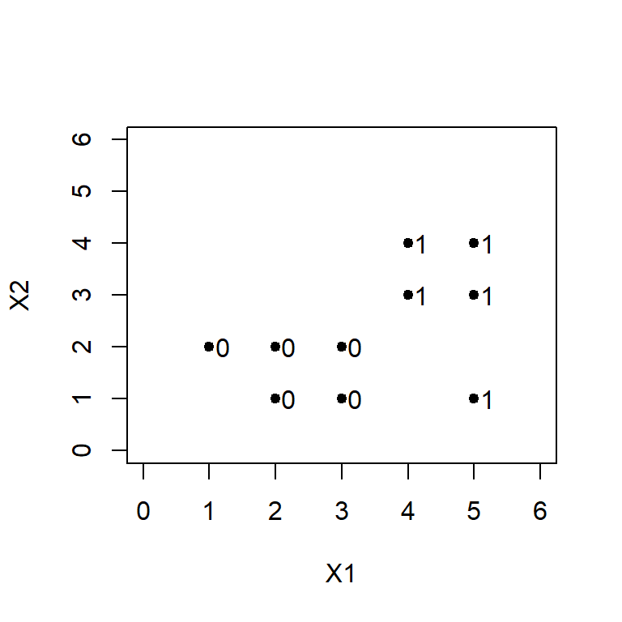

```r
X1 <- c(1, 2, 3, 2, 5, 5, 3, 4, 4, 5)
X2 <- c(2, 1, 1, 2, 1, 3, 2, 3, 4, 4)
Y <- c(0, 0, 0, 0, 1, 1, 0, 1, 1, 1)
plot(X1, X2, xlab = "X1", ylab = "X2", pch = 20, xlim = c(0,6), ylim = c(0,6), cex = 1.2)
text(X1 + 0.2, X2, Y, cex = 1)
```

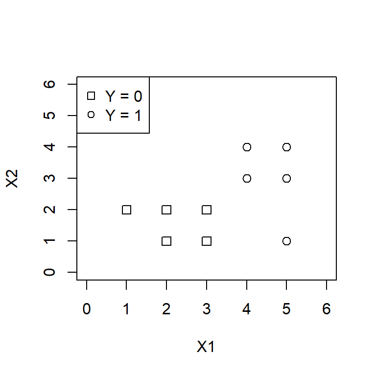

```r
X1 <- c(1, 2, 3, 2, 5, 5, 3, 4, 4, 5)
X2 <- c(2, 1, 1, 2, 1, 3, 2, 3, 4, 4)
Y <- c(0, 0, 0, 0, 1, 1, 0, 1, 1, 1)
plot(X1, X2, xlab = "X1", ylab = "X2", pch = as.integer(Y), xlim = c(0,6), ylim = c(0,6), cex = 1.2)
legend('topleft', legend = c('Y = 0','Y = 1'), pch = 0:1, cex = 1)
```

- En ambas gráficas podemos observar que los dos grupos se pueden separar muy bien con rectas.
- Por lo tanto nuestro modelo será
  $$h_{\boldsymbol \theta}(\mathbf x) = g(\theta_0 + \theta_1 x_1 + \theta_2 x_2) \, .$$
- Otra forma de analizar los grupos es calcular medidas descriptivas en cada uno de ellos.
  - Por ejemplo podemos calcular las medias en cada grupo:

```r
X1 <- c(1, 2, 3, 2, 5, 5, 3, 4, 4, 5)
X2 <- c(2, 1, 1, 2, 1, 3, 2, 3, 4, 4)
Y <- c(0, 0, 0, 0, 1, 1, 0, 1, 1, 1)
tmp1 = tapply(X1, Y, mean)
tmp2 = tapply(X2, Y, mean)
tmp = rbind(tmp1, tmp2)
colnames(tmp) = paste0("Y = ", colnames(tmp))
rownames(tmp) = paste0("Media de ", c("X1", "X2"))
tmp
```

```
            Y = 0 Y = 1
Media de X1   2.2   4.6
Media de X2   1.6   3.0
```

- Estas diferencias también se pueden ver representado $x^{(i)}$ frente a $Y$.

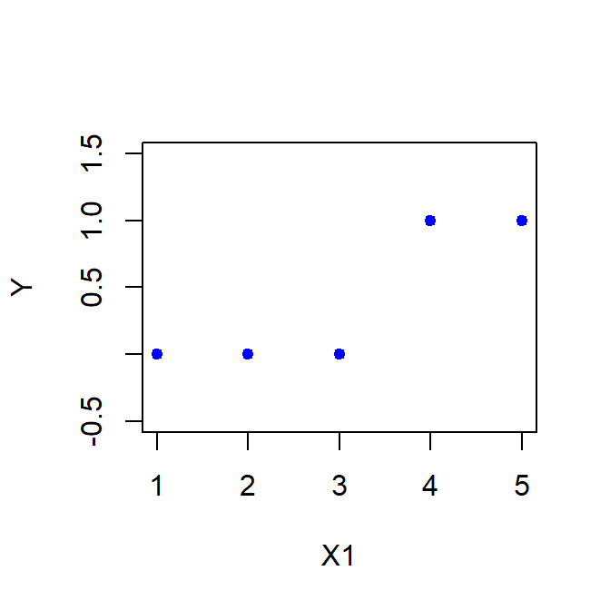

```r
X1 <- c(1, 2, 3, 2, 5, 5, 3, 4, 4, 5)
Y <- c(0, 0, 0, 0, 1, 1, 0, 1, 1, 1)
plot(X1, Y, ylim = c(-0.5, 1.5), cex = 1.2, pch = 20, col = "blue")
```

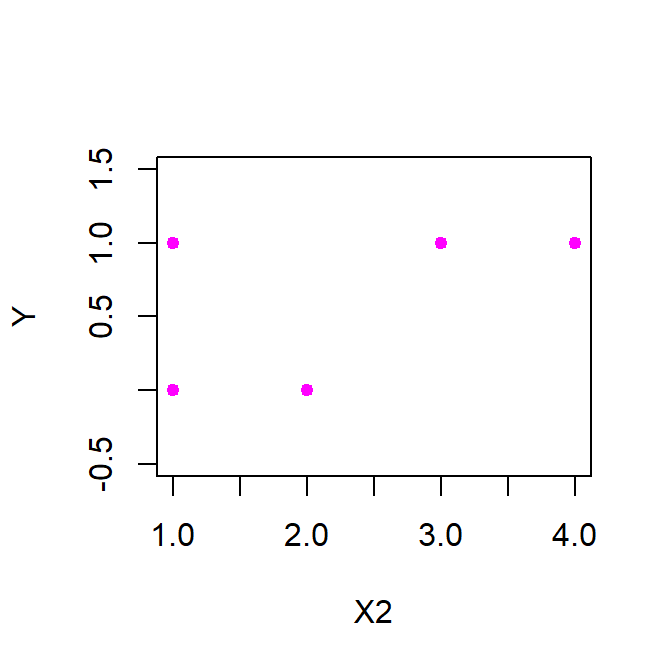

```r
X2 <- c(2, 1, 1, 2, 1, 3, 2, 3, 4, 4)
Y <- c(0, 0, 0, 0, 1, 1, 0, 1, 1, 1)
plot(X2, Y, ylim = c(-0.5, 1.5), cex = 1.2, pch = 20, col = "magenta")
```

- Podemos observar cómo la primera variable separa mejor a los grupos que la segunda (en los valores muestrales).
- De forma similar se pueden representar histogramas o diagramas caja-bigote para comparar las variables en cada grupo.
- Podemos calcular la función $J(\boldsymbol \theta)$ en `R` con los datos anteriores.

```r
X1 <- c(1, 2, 3, 2, 5, 5, 3, 4, 4, 5)
X2 <- c(2, 1, 1, 2, 1, 3, 2, 3, 4, 4)
Y <- c(0, 0, 0, 0, 1, 1, 0, 1, 1, 1)
n <- length(Y)
k <- 2
X0 = rep(1, n)
M <- matrix(c(X0, X1, X2), nrow = n, ncol = k + 1, byrow = FALSE)
g <- function(z){
  g = exp(z)/(1 + exp(z))
  return(g)
}
J <- function(theta){
  J = - sum(Y * log(g(M %*% theta)) + (1 - Y) * log(1 - g(M %*% theta)))/n
  return(J)
}
```

- Podemos aplicar un `método iterativo` para la obtención del óptimo.
  - Por ejemplo, el `método del gradiente descendiente` (se detallará su aplicación en la práctica complementaria de regresión logística).

```r
z <- c(-3.5, 1, 0)
alpha <- 1/3
m <- 1000
J1 <- 1:m
for (i in 1:m) {
  h <- g(M %*% z)
  z <- z - (alpha/n) * t(M) %*% (h-Y)
  J1[i] <- J(z)
}
```

- Partiendo del punto inicial $\boldsymbol \theta^{(0)} = (-3.5, 1, 0)$ (recta vertical de separación $x_1 = 3.5$) y después de `1000 iteraciones` obtendremos $\hat \theta_0$ = -10.7505, $\hat \theta_1$ = 2.4594 y $\hat \theta_3$ = 1.0287, con valor de $J(\hat {\boldsymbol \theta})$ = 0.0597.
- En este caso,
  - $I_{\hat {\boldsymbol \theta}}(x_1, x_2)$ = -10.7505 + 2.4594 $x_1$ + 1.0287 $x_2$.
- La recta que marca la frontera de esta solución será
  - -10.7505 + 2.4594 $x_1$ + 1.0287 $x_2$ = 0.
- Esto es, $x_2$ = 10.4506 - 2.3908 $x_1$.
- Si queremos `predecir` el grupo para un nuevo individuo con valores $x_1 = 5$ y $x_2 = 2$,
  - evaluamos la función $I_{\hat {\boldsymbol \theta}}(x_1, x_2)$ = -10.7505 + 2.4594 $x_1$ + 1.0287 $x_2$,
  - $I_{\hat {\boldsymbol \theta}}(5, 2)$ = 3.6037 > 0, por lo que el individuo se clasifica en el grupo $y = 1$.
- Representamos los valores muestrales incluyendo la recta que marca la frontera y el punto $(5, 2)$.

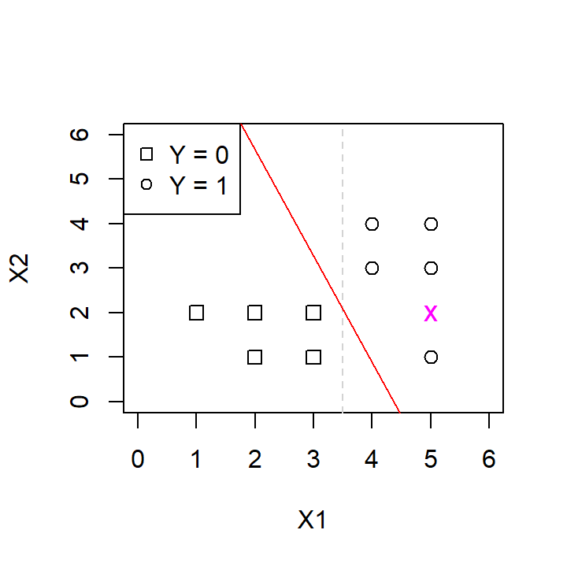

```r
plot(X1, X2, xlab = "X1", ylab = "X2", pch = as.integer(Y), xlim = c(0,6), ylim = c(0,6), cex = 1.2)
legend('topleft', legend = c('Y = 0','Y = 1'), pch = 0:1, cex = 1)
abline(v = 3.5, col = "lightgray", lty = 2)
abline(-z[1]/z[3],-z[2]/z[3],col='red')
text(5, 2, 'x', col = "magenta", cex = 1.2)
```

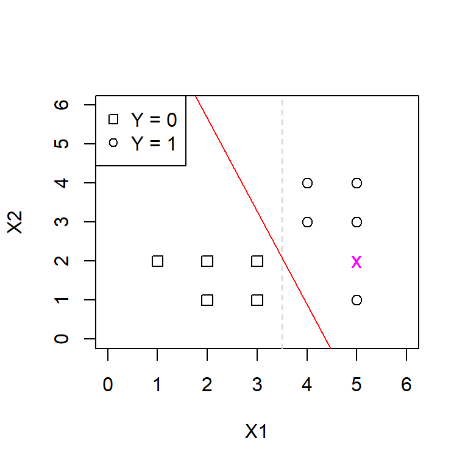

```r
plot(X1, X2, xlab = "X1", ylab = "X2", pch = as.integer(Y), xlim = c(0,6), ylim = c(0,6), cex = 1.2)
legend('topleft', legend = c('Y = 0','Y = 1'), pch = 0:1, cex = 1)
abline(v = 3.5, col = "lightgray", lty = 2)
abline(-z[1]/z[3],-z[2]/z[3],col='red')
text(5, 2, 'x', col = "magenta", cex = 1.2)
```

- Para medir cómo de fiable es esta clasificación podemos
  - observar cómo se distribuyen los puntos en esta gráfica (cuando sea posible) o
  - calcular las `probabilidades a posteriori`.
- $Pr(Y = 1 |X_1 = 5, X_2 = 2) \approx g(I_{\hat {\boldsymbol \theta}}(5,2))$ = 0.9735.
- $Pr(Y = 0 |X_1 = 5, X_2 = 2) \approx 1- g(I_{\hat {\boldsymbol \theta}}(5,2))$ = 0.0265.
- Observando la gráfica con los valores muestrales parece razonable que el nuevo individuo con valores $\mathbf x = (5, 2)$ sea clasificado en el grupo $y = 1$.
- Ahora queremos `predecir` el grupo para otro nuevo individuo con valores $x_1 = 3.5$ y $x_2 = 2$. En este caso,
  - $I_{\hat {\boldsymbol \theta}}(x_1, x_2)$ = -0.0853 < 0, por lo que el individuo se clasifica en el grupo $y = 0$.
- Representamos gráficamente.

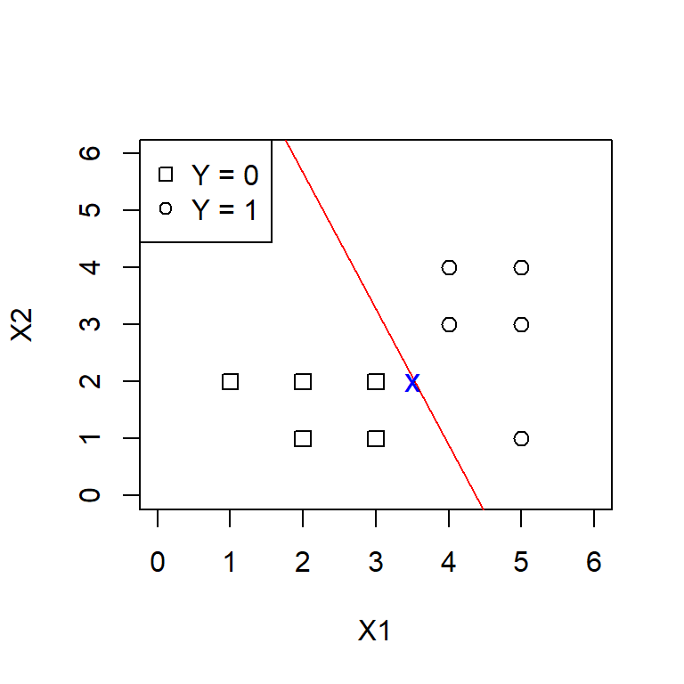

```r
plot(X1, X2, xlab = "X1", ylab = "X2", pch = as.integer(Y), xlim = c(0,6), ylim = c(0,6), cex = 1.2)
legend('topleft', legend = c('Y = 0','Y = 1'), pch = 0:1, cex = 1)
abline(-z[1]/z[3],-z[2]/z[3],col='red')
text(3.5, 2, 'x', col = "blue", cex = 1.2)
```

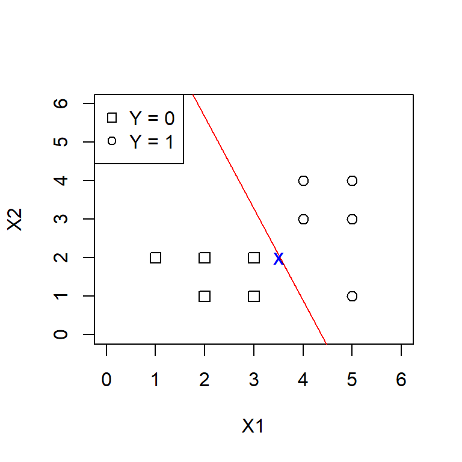

```r
plot(X1, X2, xlab = "X1", ylab = "X2", pch = as.integer(Y), xlim = c(0,6), ylim = c(0,6), cex = 1.2)
legend('topleft', legend = c('Y = 0','Y = 1'), pch = 0:1, cex = 1)
abline(-z[1]/z[3],-z[2]/z[3],col='red')
text(3.5, 2, 'x', col = "blue", cex = 1.2)
```

- Observamos dónde se encuentra el nuevo individuo en la gráfica.
- Calculamos las `probabilidades a posteriori`:
  - $Pr(Y = 1 |X_1 = 3.5, X_2 = 2) \approx g(I_{\hat {\boldsymbol \theta}}(3.5,2))$ = 0.4787.
  - $Pr(Y = 0 |X_1 = 3.5, X_2 = 2) \approx 1- g(I_{\hat {\boldsymbol \theta}}(3.5,2))$ = 0.5213.
- Recordemos que en realidad no estamos seguros de que esos valores sean realmente esas probabilidades.
- De esta forma intuimos que esta clasificación no es muy fiable ya que ese punto está `muy cerca de la frontera`.

## Regresión logística multinomial

**El contexto**

- Generalización del modelo de regresión logística binaria.
- La variable dependiente tiene `más de dos categorías`, sin/con un orden implícito.
  - Primer caso: considera variables de `respuesta nominal`,
    - Por ejemplo, el país de procedencia, el color de un automóvil, etc.
  - Segundo caso: trata variables de `respuesta ordinal`,
    - Por ejemplo, el nivel educativo, la fase de una enfermedad, etc.

**Objetivo**

- Estimar la probabilidad de que un individuo presente cada una de estas categorías en función de los valores que se observen de las variables explicativas.

## Modelo teórico

**Formulación**

- La variable respuesta $Y$ puede presentar $g$ `categorías`.
  - $Y$ toma los valores $1, 2, \dots, g$, que indican la pertenencia a cada grupo definido por cada categoría, con probabilidades $p_1, p_2, \cdots, p_g$, respectivamente, tales que
    $$\displaystyle \sum_{j=1}^g p_j = 1 \, .$$
- Consideramos como referencia una de las categorías, por ejemplo, la última, $g$.
- Establecemos un modelo `logit` para cada categoría con respecto a esta:
  $$\log \frac{p_j}{p_g} = \log \frac{Pr[Y = j]}{Pr[Y = g]} = \boldsymbol \theta_j ' \mathbf X , \quad j = 1, \dots, g-1 \, ,$$
  donde $\boldsymbol \theta_j = (\theta_{j0}, \dots, \theta_{jk})' \in \mathbb R^{k+1}$ contiene los parámetros del modelo para cada categoría $j$ y $\mathbf X = (X_0, \dots, X_k)'$ las variables que podemos medir en nuestros individuos para predecir $Y$.
- Al cociente $\displaystyle \frac{p_j}{p_g}$ se le denomina `odds` de la categoría $j$ respecto de la categoría $g$.
- Se ha considerado un término constante en el modelo incluyendo la variable artificial $X_0$ que siempre vale 1.
- Cada uno de los coeficientes se interpreta como el efecto de cada variable explicativa sobre el logaritmo de los `odds` de la categoría $j$ respecto de la categoría de referencia $g$.
- Cuando $g=2$, el modelo se reduce a una única ecuación equivalente a la propuesta en la regresión logística.

**Observaciones**

- Si comparamos las probabilidades para dos categorías diferentes, $i$ y $j$, utilizando el modelo anterior obtenemos que:
  $$\begin{equation*}
  \begin{split}
  \log \frac{p_i}{p_j} & = \log \frac{\displaystyle \frac{p_i}{p_g}}{\displaystyle \frac{p_j}{p_g}} =
  \log \frac{p_i}{p_g} - \log \frac{p_j}{p_g}
  = \boldsymbol \theta_i ' \mathbf X - \boldsymbol \theta_j ' \mathbf X \\
  & = ( \boldsymbol \theta_i - \boldsymbol \theta_j)'\mathbf X =
  (\theta_{i0} - \theta_{j0}) + (\theta_{i1} - \theta_{j1}) X_1 +
  \cdots (\theta_{ik} - \theta_{jk}) X_k \, .
  \end{split}
  \end{equation*}$$
  - De esta forma, se obtiene una ecuación `logit` de la categoría $i$ con respecto a la categoría $j$, donde $\theta_0 = \theta_{i0} - \theta_{j0}$, $\theta_1 = \theta_{i1} - \theta_{j1}$,…, $\theta_k = \theta_{ik} - \theta_{jk}$.

**Un ejemplo ficticio**

- Supongamos que deseamos estudiar cómo influye el sexo del neonato en la aparición de determinados problemas durante el parto.
- Se contemplan únicamente tres opciones posibles para los partos ($Y$):
  - $Y = 1$: parto con el problema A
  - $Y = 2$: parto con el problema B
  - $Y = 3$: parto sin problemas
- La tercera opción se toma como la opción de referencia.
- Se introduce una variable binaria $X$ para representar el sexo del neonato:
  - $X = 0$: si es niño
  - $X = 1$: si es niña
- Planteamos un modelo de regresión logística para predecir la variable categórica $Y$ en función de $X$:
  $$\log \frac{p_j}{p_3} = \log \frac{Pr[Y = j]}{Pr[Y=3]} = \theta_{j0} + \theta_{j1} x \, , \quad j = 1, 2.$$

**Interpretación de los parámetros**

- Considerando la primera de las ecuaciones:
  $$\log \frac{p_1}{p_3} = \log \frac{Pr[Y = 1]}{Pr[Y=3]} = \theta_{10} + \theta_{11}x \, ,$$
  - Si $X = 0$, $\displaystyle \frac{p_1}{p_3} = \exp(\theta_{10}) \, .$
  - Si $X = 1$, $\displaystyle \frac{p_1}{p_3} = \exp(\theta_{10} + \theta_{11}) \, .$
- Por lo tanto, respecto a la probabilidad de un parto normal,
  - la probabilidad de la presencia del problema A se multiplica por $\exp(\theta_{10})$ en el caso de niños y por $\exp(\theta_{10} + \theta_{11})$ en el caso de niñas.
- Si, por ejemplo, resultara $\theta_{11} = 0$,
  - el sexo no influiría sobre la probabilidad de que aparezca el problema A.
- Razonando de forma análoga, si resultara $\theta_{21}>0$ se concluiría que la aparición del problema B es más probable en niñas que en niños.

## Recordemos…

**Estimador de máxima verosimilitud**

- Sea $X$ una variable aleatoria, con función de densidad o función puntual de probabilidad $x\mapsto f_X(x; \boldsymbol \theta)$, donde $\boldsymbol \theta \in\Theta\subset \mathbb{R}^k$.
- Consideramos una m.a.s $(X_1,\ldots,X_n)$.
- Para un valor concreto de $(X_1,\ldots,X_n)$, que denotamos por $(x_1,\ldots,x_n)$, la `función de verosimilitud` $L_n$ es una función de $\boldsymbol \theta$, $L_n:\Theta\subset\mathbb{R}^k\to \mathbb{R}^+$, definida como
  $$L_n(\boldsymbol \theta)=f_{X_1,\ldots,X_n}(x_1,\ldots,x_n; \boldsymbol \theta) = \displaystyle \prod_{i = 1}^n f_{\mathbf X}(x_i; \boldsymbol \theta) \, .$$
- El `estimador de máxima verosimilitud` $\hat{\boldsymbol \theta}$ de $\boldsymbol \theta$ es cualquier valor de $\boldsymbol \theta$ admisible que maximiza la función $L_n(\boldsymbol \theta)$,
  $$\hat{\boldsymbol \theta}= \arg \max_{\boldsymbol \theta \in \Theta} L_n(\boldsymbol \theta) \, .$$

## Criterio de máxima de verosimilitud para nuestro modelo

**Criterio**

- Para estimar los parámetros del modelo utilizaremos el criterio de máxima verosimilitud:
  - Calculamos la función de verosimilitud
  - Maximizamos esta función para obtener los estimadores de máxima verosimilitud (MLE, `maximum likelihood estimator`).
- Redefiniremos la variable $Y$ en $g$ variables indicadoras $(Y_1, \dots, Y_{g})$:
  - $Y_j$ toma el valor 1 si la respuesta pertenece al grupo $j$ y 0 en otro caso.
  - Tendremos que $\displaystyle \sum_{j=1}^g Y_j = 1$.

**Función de verosimilitud**

- Supongamos que disponemos de $n$ observaciones independientes de la variable $Y$ y de las variables explicativas.Para cada individuo $i$ tendremos:
  - Las observaciones $(y_1^{(i)}, \dots, y_g^{(i)})$, donde
    $$\displaystyle \sum_{j=1}^g y_j^{(i)} = 1 \, .$$
  - Los valores de las variables explicativas observados $\mathbf x^{(i)} = (x_0^{(i)}, \dots, x_k^{(i)})' \, .$
- Entonces, la `función de verosimilitud` adopta la expresión
  $$L(\boldsymbol \theta_1, \dots \boldsymbol \theta_{g-1})
  \propto \prod_{i=1}^n \prod_{j=1}^g p_j(\mathbf x^{(i)})^{y_j^{(i)}} \, .$$
  donde el símbolo $\propto$ indica `proporcional a`.

**Función de log-verosimilitud**

- En lugar de maximizar directamente la función de verosimilitud consideraremos su logaritmo neperiano:
  - función más manejable que simplifica los cálculos,
  - permite utilizar métodos numéricos de optimización más eficientes y estables al transformar productos en sumas.
- La log-verosimilitud adopta la expresión
  $$\log L(\boldsymbol \theta_1, \dots \boldsymbol \theta_{g-1})
  \propto \log \prod_{i=1}^n \prod_{j=1}^g p_j
  (\mathbf x^{(i)})^{y_j^{(i)}} =
  \sum_{i=1}^n \sum_{j=1}^g y_j^{(i)} \log p_j(\mathbf x^{(i)}) \, .$$
- En términos de una función costo, el criterio de máxima verosimilitud equivale a minimizar la función
  $$J(\boldsymbol \theta_1, \dots \boldsymbol \theta_{g-1}) = - \log L(\boldsymbol \theta_1, \dots \boldsymbol \theta_{g-1}) \, .$$
- En ocasiones en lugar de la función de log-verosimilitud se utiliza la función auxiliar $\Lambda = - 2 \log L$, denominada la `deviance` del modelo.
- Puesto que $p_g = 1- (p_1 + \dots p_{g-1})$, la contribución del individuo $i$ en la función de la log-verosimilitud sería
  $$\begin{split}
  \sum_{j=1}^g y_j^{(i)} \log p_j(\mathbf x^{(i)}) = &
  \sum_{j=1}^{g-1} y_j^{(i)} \log p_j(\mathbf x^{(i)}) +
  \\
  & \left ( 1- \sum_{j=1}^{g-1} y_j^{(i)} \right )
  \log \left ( 1- \sum_{j=1}^{g-1} p_j(\mathbf x^{(i)}) \right ) \\
  = &
  \sum_{j=1}^{g-1} y_j^{(i)} \log
  \frac{p_j(\mathbf x^{(i)})}{1- \displaystyle \sum_{h=1}^{g-1} p_h(\mathbf x^{(i)})} + \log \left (1- \sum_{j=1}^{g-1} p_j(\mathbf x^{(i)}) \right ) \, . \end{split}$$
- Según el modelo logístico multinomial,
  $$\log \frac{p_j(\mathbf x^{(i)})}{p_g(\mathbf x^{(i)})} =
  \boldsymbol \theta_j ' \mathbf x^{(i)} \, .$$
- Por otra parte, $p_g(\mathbf x^{(i)})$ puede escribirse como
  $$p_g(\mathbf x^{(i)}) = 1- \sum_{j=1}^{g-1} p_j(\mathbf x^{(i)}) = 1 - p_g(\mathbf x^{(i)}) \sum_{j=1}^{g-1} \exp(\boldsymbol \theta_j ' \mathbf x^{(i)}) \, ,$$
- Y despejando ahora $p_g(\mathbf x^{(i)})$ en la expresión anterior se obtiene que
  $$p_g(\mathbf x^{(i)}) = \frac{1}{1+ \displaystyle \sum_{h=1}^{g-1}\exp{(\boldsymbol \theta_j ' \mathbf x^{(i)})}} \, .$$
- Y por tanto,
  $$p_j(\mathbf x^{(i)}) = \frac{\exp(\boldsymbol \theta_j ' \mathbf x^{(i)})}{1+ \displaystyle \sum_{h=1}^{g-1}\exp(\boldsymbol \theta_h ' \mathbf x^{(i)})} \, .$$
- Sustituyendo ahora en la función de log-verosimilitud se tendrá que
  $$\begin{equation}\begin{split}
  \log L(\boldsymbol \theta_1, \dots \boldsymbol \theta_{g-1})
  & \propto
  \sum_{i=1}^n \sum_{j=1}^g y_j^{(i)} \log p_j(\mathbf x^{(i)}) \\
  & =
  \sum_{i=1}^n
  \left [
  \sum_{j=1}^{g-1} y_j^{(i)} (\boldsymbol \theta_j ' \mathbf x^{(i)}) -
  \log \left (
  1 + \sum_{j=1}^{g-1} \exp(\boldsymbol \theta_j' \mathbf x^{(i)})
  \right )
  \right ] \\
  & =
  \sum_{i=1}^n \sum_{j=1}^{g-1}
  y_j^{(i)} (\boldsymbol \theta_j ' \mathbf x^{(i)}) -
  \sum_{i=1}^n \log \left (
  1 + \sum_{j=1}^{g-1} \exp(\boldsymbol \theta_j' \mathbf x^{(i)})
  \right )
  \end{split}
  \end{equation}$$

**¿Cómo obtenemos en la práctica las estimaciones de $\boldsymbol \theta_1 \dots, \boldsymbol \theta_{g-1}$?**

- Para obtener valores de los parámetros $\boldsymbol \theta_1 \dots, \boldsymbol \theta_{g-1}$ que maximicen la log-verosimilitud (o equivalentemente, minimicen la función costo $J$), podremos
  - Aplicar algoritmos iterativos de búsqueda como el algoritmo del gradiente descendente.
  - Hacer uso de funciones implementadas en librerías de `R` que permiten obtener estimaciones de los parámetros del modelo logístico multinomial, como la función `multinom()` de la librería `nnet`.
    - Práctica de regresión logística multinomial.

## Un caso sencillo

**Cálculo de la verosimilitud**

- Supongamos que tenemos una variable respuesta ($Y$) con tres categorías posibles y dos variables explicativas $X_1$ y $X_2$, cuyas observaciones están recogidas en la tabla adjunta.

$$\scriptsize
\begin{array}{c|ccc}
\mbox{Individuo} & X_1 & X_2 & Y \\ \hline
1 & 1 & 2 & 2 \\
2 & 2 & 1 & 2 \\
3 & 1 & 5 & 3 \\
4 & 2 & 4 & 3 \\
5 & 3 & 1 & 2 \\
6 & 2 & 2 & 2 \\
7 & 2 & 5 & 3 \\
8 & 5 & 1 & 1 \\
9 & 5 & 3 & 1 \\
10 & 3 & 2 & 2 \\
11 & 4 & 3 & 1 \\
12 & 4 & 4 & 1 \\
13 & 5 & 4 & 1 \\
14 & 1 & 4 & 3 \\ \hline
\end{array}$$

- Para la implementación en `R` de estos cálculos introduciremos los datos en vectores y representaremos los datos gráficamente.

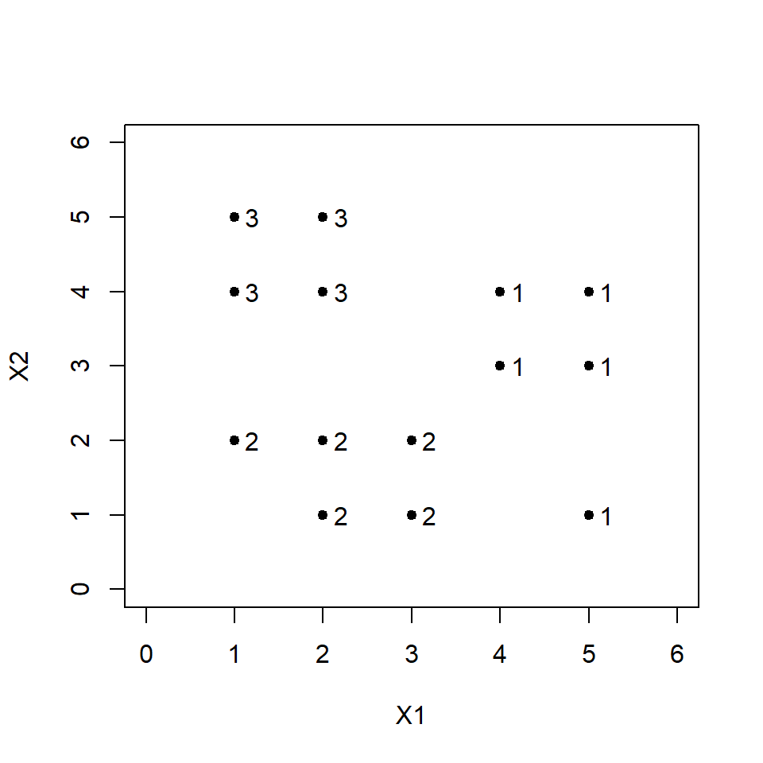

```r
X1 <- c(1, 2, 1, 2, 3, 2, 2, 5, 5, 3, 4, 4, 5, 1)
X2 <- c(2, 1, 5, 4, 1, 2, 5, 1, 3, 2, 3, 4, 4, 4)
Y  <- c(2, 2, 3, 3, 2, 2, 3, 1, 1, 2, 1, 1, 1, 3)
plot(X1, X2, xlab = "X1", ylab = "X2", pch = 20, xlim = c(0,6), ylim = c(0,6), cex = 1.2)
text(X1 + 0.2, X2, Y, cex = 1)
```

- Incluimos los valores de la variable artificial $X_0 = 1$.
- Asociada a la variable $Y$ definimos tres variables indicadoras, $Y_j$, $j= 1, 2, 3$, de manera que $Y_j = 1$ si $Y=j$ y 0 en otro caso.

```r
library("dplyr")
X1 <- c(1, 2, 1, 2, 3, 2, 2, 5, 5, 3, 4, 4, 5, 1)
X2 <- c(2, 1, 5, 4, 1, 2, 5, 1, 3, 2, 3, 4, 4, 4)
Y  <- c(2, 2, 3, 3, 2, 2, 3, 1, 1, 2, 1, 1, 1, 3)
df = data.frame(X1, X2, Y)
df <- df %>%
  mutate(X0 = 1,
         Y1 = ifelse(Y == 1, 1, 0),
         Y2 = ifelse(Y == 2, 1, 0),
         Y3 = ifelse(Y == 3, 1, 0))
df
```

```
   X1 X2 Y X0 Y1 Y2 Y3
1   1  2 2  1  0  1  0
2   2  1 2  1  0  1  0
3   1  5 3  1  0  0  1
4   2  4 3  1  0  0  1
5   3  1 2  1  0  1  0
6   2  2 2  1  0  1  0
7   2  5 3  1  0  0  1
8   5  1 1  1  1  0  0
9   5  3 1  1  1  0  0
10  3  2 2  1  0  1  0
11  4  3 1  1  1  0  0
12  4  4 1  1  1  0  0
13  5  4 1  1  1  0  0
14  1  4 3  1  0  0  1
```

- Empezamos implementando la función `J` utilizando código en `R`.

```r
J <- function(theta){
  C = exp(t(theta)%*%t(X))
  D = colSums(C)
  E = matrix(rep(1 + D, g - 1), nrow = g - 1, ncol = n, byrow = TRUE)
  P = C/E
  Pg = 1/(1+D)
  PT =  rbind(P, Pg)
  J = -sum(YY*log(t(PT)))
  return(J)
}
```

- Introducimos los valores muestrales de las variables.

```r
library("dplyr")
n = length(Y)
g = 3
k = 2
X1 <-c(1, 2, 1, 2, 3, 2, 2, 5, 5, 3, 4, 4, 5, 1)
X2 <-c(2, 1, 5, 4, 1, 2, 5, 1, 3, 2, 3, 4, 4, 4)
Y  <-c(2, 2, 3, 3, 2, 2, 3, 1, 1, 2, 1, 1, 1, 3)
df = data.frame(X1, X2, Y)
df <- df %>%
  mutate(X0 = 1,
         Y1 = ifelse(Y == 1, 1, 0),
         Y2 = ifelse(Y == 2, 1, 0),
         Y3 = ifelse(Y == 3, 1, 0))
X = as.matrix(df[, c("X0", "X1", "X2")])
YY = as.matrix(df[, c("Y1", "Y2", "Y3")])
```

- Evaluamos en
  $$\boldsymbol \theta = \left ( \begin{array}{cc}
  1 & 2 \\
  0 & 1 \\
  2 & 3
  \end{array}
  \right )$$

```r
theta = matrix(c(1, 2,
                 0, 1,
                 2, 3), nrow = k+1, ncol = g-1, byrow = TRUE)
J(theta)
```

```
[1] 111.0598
```

- Evaluamos en
  $$\boldsymbol \theta = \left ( \begin{array}{cc}
  -2.3 & 1.5 \\
  0.5 & 2 \\
  2.1 & 3.5
  \end{array}
  \right )$$

```r
theta = matrix(c(-2.3, 1.5,
                 0.5, 2,
                 2.1, 3.5), nrow = k+1, ncol = g-1, byrow = TRUE)
J(theta)
```

```
[1] 155.5009
```

**Estimación de los parámetros**

- Utilizaremos la función `multinom()` de la librería `nnet` de R.
  - Las opciones de esta función se verán con más detalle en la práctica de regresión logística multinomial.

```r
library("nnet")
X1 <-c(1, 2, 1, 2, 3, 2, 2, 5, 5, 3, 4, 4, 5, 1)
X2 <-c(2, 1, 5, 4, 1, 2, 5, 1, 3, 2, 3, 4, 4, 4)
Y  <-c(2, 2, 3, 3, 2, 2, 3, 1, 1, 2, 1, 1, 1, 3)
df = data.frame(X1, X2, Y)
df$Y_factor = factor(df$Y, levels = c("1", "2", "3"))
df$Y_factor <- relevel(df$Y_factor, ref = "3")
mymultinom <- multinom(Y_factor ~ X1 +  X2, data = df)
```

```r
summary(mymultinom)$coefficients
```

```
  (Intercept)        X1         X2
1   -19.79766 12.677892  -5.560149
2    27.10762  2.521385 -10.282168
```

**Modelo estimado**

- Ecuaciones del `modelo estimado`:

$$\displaystyle \log \frac{p_1}{p_3} = -19.798 + 12.678 x_1 -5.56 x_2$$

$$\displaystyle \log \frac{p_2}{p_3} = 27.108 + 2.521 x_1 -10.282 x_2$$

- Recordemos que los coeficientes del modelo miden la variación del logaritmo de los `odds` por unidad de cambio en el correspondiente predictor.
- Tomando exponenciales sobre los coeficientes, medimos las variaciones producidas sobre los `odds` directamente.
- El algoritmo ha parado después de 100 iteraciones.
- Valor de la $-\log L$: 0.0019242
- Valor de la `deviance` del modelo: 0.0038484

## Modelo logístico multinomial con categorías ordinales

**Modelo teórico**

- Este tipo de modelo se utiliza cuando las categorías de la variable dependiente representan un orden lógico o jerarquía.
- Expresión general del `modelo`:
  $$\log \frac{Pr[Y \leq j]}{1 - Pr[Y \leq j]} = \boldsymbol \theta_j ' \mathbf X , \quad j = 1, \dots, g-1 \, ,$$
  donde $\boldsymbol \theta_j = (\theta_{j0}, \dots, \theta_{jk})' \in \mathbb R^{k+1}$ contiene los parámetros del modelo para cada categoría $j$ y $\mathbf X = (X_0, \dots, X_k)'$ las variables que podemos medir en nuestros individuos para predecir $Y$.
- `Interpretación de los coeficientes`: entender cómo un cambio en una variable predictora afecta a la razón de probabilidades de que la variable dependiente sea menor o igual a una categoría específica en comparación con las categorías superiores.

[figure not shown]

Análisis Estadístico Multivariante, GCID